# Grouping OLS predictions

Philip suggested I should try grouping the results I had using OLS regressions into the 4 groups, and see if there is any difference there.

```r
library(gdata)
library(nnet)
load('~/data/baseline_prediction/combined_descriptives_12172018.RData.gz')
clin = read.csv('~/data/baseline_prediction/long_clin_11302018.csv')
df = merge(clin, data, by='MRN')
idx = df$diag_group != 'new_onset'
idx2 = !is.na(df$inatt_vol_lh) | !is.na(df$inatt_AD_clu1) | !is.na(df$inatt_melodic_DMN)
imaging = df[idx & idx2,]
imaging[imaging$OLS_inatt_slope <= -.33, 'OLS_inatt_categ'] = 'marked'
imaging[imaging$OLS_inatt_slope > -.33 & imaging$OLS_inatt_slope <= 0, 'OLS_inatt_categ'] = 'mild'
imaging[imaging$OLS_inatt_slope > 0, 'OLS_inatt_categ'] = 'deter'
imaging[imaging$DX == 'NV', 'OLS_inatt_categ'] = 'NV'
imaging$OLS_inatt_categ = as.factor(imaging$OLS_inatt_categ)
imaging$OLS_inatt_categ = relevel(imaging$OLS_inatt_categ, ref='NV')
load('~/data/baseline_prediction/combined_descriptives_12172018.RData.gz')
clin = read.csv('~/data/baseline_prediction/long_clin_11302018.csv')
df = merge(clin, data, by='MRN')
idx = df$diag_group != 'new_onset'
struct = df[!is.na(df$HI_vol_rh) & idx,]
load('~/data/baseline_prediction/struct_volume_11142018_260timeDiff12mo.RData.gz')
struct = merge(struct, data, by='MRN') # put mask ids in combined dataset
mprage = read.xls('~/data/baseline_prediction/long_scans_08072018.xlsx',
                  sheet='mprage')
struct = merge(struct, mprage, by.x='mask.id', by.y='Mask.ID...Scan') # get demographics
qc = read.csv('~/data/baseline_prediction/master_qc.csv')
struct = merge(struct, qc, by.x='mask.id', by.y='Mask.ID') # get QC scores
df = merge(struct, imaging, by='MRN')
dim(df)
```

```
[1]  241 5244
```

```r
pairwise.t.test(df$inatt_vol_lh.x, df$OLS_inatt_categ, p.adjust.method='none')
```

```
    Pairwise comparisons using t tests with pooled SD

data:  df$inatt_vol_lh.x and df$OLS_inatt_categ

       NV      deter   marked
deter  0.11032 -       -
marked 0.01310 0.00037 -
mild   0.94330 0.19080 0.05396

P value adjustment method: none
```

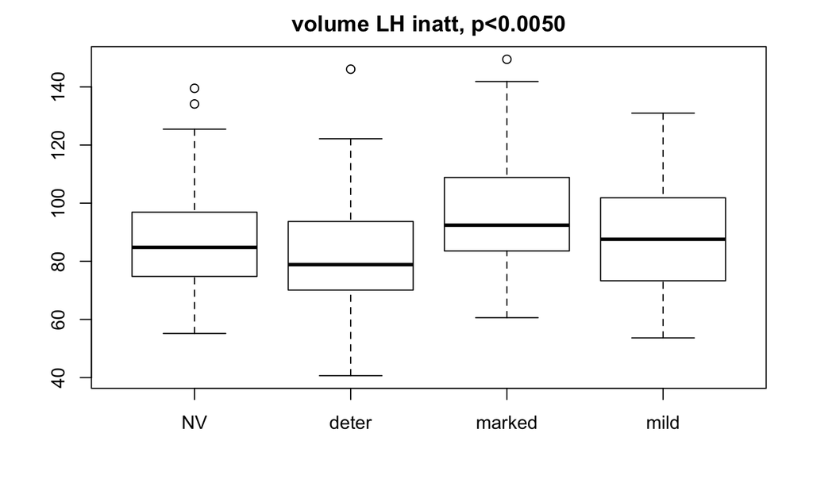

```r
fm = as.formula(df$inatt_vol_lh.x ~ df$OLS_inatt_categ)
fit = aov(lm(fm))
boxplot(fm)
title(sprintf('volume LH inatt, p<%.4f', summary(fit)[[1]][1, 'Pr(>F)']))
```

So, the idea now is to regress out some of these significant variables to see what happens, and also try to make the NVs a bit more pure (i.e. flat OLS only).

```r
bad_nvs = df$OLS_inatt_categ == 'NV' & df$OLS_inatt_slope.x != 0
df_clean = df[!bad_nvs, ]
dim(df_clean)
```

```
[1]  209 5244
```

Now we figure out how the cluster looks like without any possible significant variables:

```r
library(MASS)
res.lm <- lm(inatt_vol_lh.x ~ Sex...Subjects + int_avg_freesurfer5.3 + age_at_scan + I(age_at_scan^2) + ext_avg_freesurfer5.3 + int_avg_freesurfer5.3 + mprage_QC, data = df_clean)
step <- stepAIC(res.lm, direction = "both", trace = F)
print(summary(step))
```

```
Call:
lm(formula = inatt_vol_lh.x ~ Sex...Subjects + int_avg_freesurfer5.3 +
    age_at_scan + I(age_at_scan^2), data = df_clean)

Residuals:
    Min      1Q  Median      3Q     Max
-44.904 -13.113  -2.373  10.185  61.323

Coefficients:
                      Estimate Std. Error t value Pr(>|t|)
(Intercept)            47.7115    21.3821   2.231  0.02674 *
Sex...SubjectsMale      8.1587     2.8195   2.894  0.00422 **
int_avg_freesurfer5.3  -6.7605     3.6939  -1.830  0.06868 .
age_at_scan             9.9104     4.1649   2.379  0.01826 *
I(age_at_scan^2)       -0.4852     0.2105  -2.305  0.02219 *
---
Signif. codes:  0 ‘***’ 0.001 ‘**’ 0.01 ‘*’ 0.05 ‘.’ 0.1 ‘ ’ 1

Residual standard error: 18.76 on 204 degrees of freedom
Multiple R-squared:  0.08442,   Adjusted R-squared:  0.06647
F-statistic: 4.703 on 4 and 204 DF,  p-value: 0.00119
```

```r
mycluster = residuals(step)
summary(aov(lm(mycluster ~ df_clean$OLS_inatt_categ)))
```

```
                          Df Sum Sq Mean Sq F value  Pr(>F)
df_clean$OLS_inatt_categ   3   4500  1500.0   4.571 0.00402 **
Residuals                205  67275   328.2
---
Signif. codes:  0 ‘***’ 0.001 ‘**’ 0.01 ‘*’ 0.05 ‘.’ 0.1 ‘ ’ 1
```

```r
pairwise.t.test(mycluster, df_clean$OLS_inatt_categ, p.adjust.method='none')
```

```
    Pairwise comparisons using t tests with pooled SD

data:  mycluster and df_clean$OLS_inatt_categ

       NV      deter   marked
deter  0.12488 -       -
marked 0.02121 0.00031 -
mild   0.79423 0.29696 0.02627

P value adjustment method: none
```

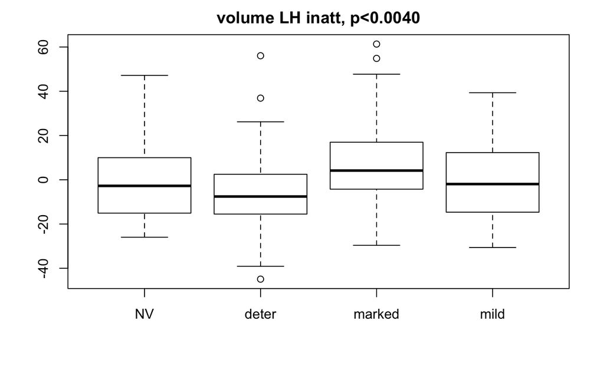

```r
fm = as.formula(mycluster ~ df_clean$OLS_inatt_categ)
fit = aov(lm(fm))
boxplot(fm)
title(sprintf('volume LH inatt, p<%.4f', summary(fit)[[1]][1, 'Pr(>F)']))
```

And of course the last thing is to run the logistic model:

```r
library(nnet)
fit <- multinom(df_clean$OLS_inatt_categ ~ scale(mycluster), na.action=na.omit)
z <- summary(fit)$coefficients/summary(fit)$standard.errors
p <- (1 - pnorm(abs(z), 0, 1)) * 2
rr = exp(coef(fit))
pp = fitted(fit)
print(p)
```

```
       (Intercept) scale(mycluster)
deter  0.338637468       0.10691729
marked 0.028934561       0.03105037
mild   0.002593892       0.78962864
```

```r
print(fit)
```

```
Call:
multinom(formula = df_clean$OLS_inatt_categ ~ scale(mycluster),
    na.action = na.omit)

Coefficients:
       (Intercept) scale(mycluster)
deter   -0.1755581      -0.32124342
marked  -0.4334711       0.40716028
mild    -0.6234285      -0.05813482

Residual Deviance: 555.4376
AIC: 567.4376
```

```r
print(rr)
```

```
       (Intercept) scale(mycluster)
deter    0.8389887        0.7252467
marked   0.6482550        1.5025449
mild     0.5361033        0.9435227
```

The only significant category when compared to NVs is marked improvement:

- A one-unit increase in the volume of the left hemisphere cluster variable (i.e. increase by 1 SD) is associated with an increase in the log odds of markedly improving (vs normals) in the amount of .41.
- In terms of relative risk ratio, a one-unit increase in the the volume of that brain cluster yields a relative risk ratio of 1.5 of marked improvement. In other words, the odds of marked improvement, compared to normals, is 1.5 times higher for every 1 SD we increase in that brain region.

We should also look at the right hemisphere results as well. Those were for HI though:

```r
load('~/data/baseline_prediction/combined_descriptives_12172018.RData.gz')
clin = read.csv('~/data/baseline_prediction/long_clin_11302018.csv')
df = merge(clin, data, by='MRN')
idx = df$diag_group != 'new_onset'
idx2 = !is.na(df$inatt_vol_lh) | !is.na(df$inatt_AD_clu1) | !is.na(df$inatt_melodic_DMN)
imaging$OLS_HI_categ = NULL
imaging[imaging$OLS_HI_slope <= -.5, 'OLS_HI_categ'] = 'marked'
imaging[imaging$OLS_HI_slope > -.5 & imaging$OLS_HI_slope <= 0, 'OLS_HI_categ'] = 'mild'
imaging[imaging$OLS_HI_slope > 0, 'OLS_HI_categ'] = 'deter'
imaging[imaging$DX == 'NV', 'OLS_HI_categ'] = 'NV'
imaging$OLS_HI_categ = as.factor(imaging$OLS_HI_categ)
imaging$OLS_HI_categ = relevel(imaging$OLS_HI_categ, ref='NV')
load('~/data/baseline_prediction/combined_descriptives_12172018.RData.gz')
clin = read.csv('~/data/baseline_prediction/long_clin_11302018.csv')
df = merge(clin, data, by='MRN')
idx = df$diag_group != 'new_onset'
struct = df[!is.na(df$HI_vol_rh) & idx,]
load('~/data/baseline_prediction/struct_volume_11142018_260timeDiff12mo.RData.gz')
struct = merge(struct, data, by='MRN') # put mask ids in combined dataset
mprage = read.xls('~/data/baseline_prediction/long_scans_08072018.xlsx',
                  sheet='mprage')
struct = merge(struct, mprage, by.x='mask.id', by.y='Mask.ID...Scan') # get demographics
qc = read.csv('~/data/baseline_prediction/master_qc.csv')
struct = merge(struct, qc, by.x='mask.id', by.y='Mask.ID') # get QC scores
df = merge(struct, imaging, by='MRN')
dim(df)
```

```
[1]  241 5245
```

```r
pairwise.t.test(df$HI_vol_rh.x, df$OLS_HI_categ, p.adjust.method='none')
```

```
    Pairwise comparisons using t tests with pooled SD

data:  df$HI_vol_rh.x and df$OLS_HI_categ

       NV     deter   marked
deter  0.0019 -       -
marked 0.0497 1.7e-05 -
mild   0.7992 0.0113  0.0729

P value adjustment method: none
```

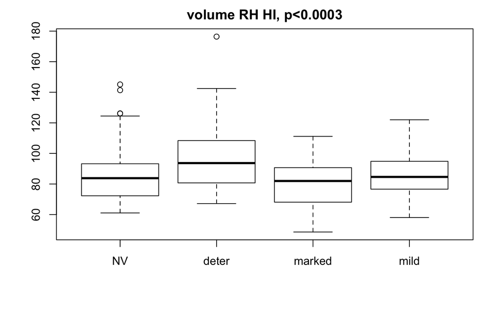

```r
fm = as.formula(df$HI_vol_rh.x ~ df$OLS_HI_categ)
fit = aov(lm(fm))
boxplot(fm)
title(sprintf('volume RH HI, p<%.4f', summary(fit)[[1]][1, 'Pr(>F)']))
```

Like before, let’s clean it up and run it again:

```r
bad_nvs = df$OLS_HI_categ == 'NV' & df$OLS_HI_slope.x != 0
df_clean = df[!bad_nvs, ]
library(MASS)
res.lm <- lm(HI_vol_rh.x ~ Sex...Subjects + int_avg_freesurfer5.3 + age_at_scan + I(age_at_scan^2) + ext_avg_freesurfer5.3 + int_avg_freesurfer5.3 + mprage_QC, data = df_clean)
step <- stepAIC(res.lm, direction = "both", trace = F)
print(summary(step))
```

```
Call:
lm(formula = HI_vol_rh.x ~ Sex...Subjects + mprage_QC, data = df_clean)

Residuals:
    Min      1Q  Median      3Q     Max
-37.588 -11.215  -1.509   7.730  88.891

Coefficients:
                   Estimate Std. Error t value Pr(>|t|)
(Intercept)          92.297      4.355  21.193  < 2e-16 ***
Sex...SubjectsMale    6.253      2.524   2.478  0.01399 *
mprage_QC            -7.363      2.576  -2.858  0.00468 **
---
Signif. codes:  0 ‘***’ 0.001 ‘**’ 0.01 ‘*’ 0.05 ‘.’ 0.1 ‘ ’ 1

Residual standard error: 17.27 on 216 degrees of freedom
Multiple R-squared:  0.06832,   Adjusted R-squared:  0.05969
F-statistic: 7.919 on 2 and 216 DF,  p-value: 0.0004796
```

```r
mycluster = residuals(step)
summary(aov(lm(mycluster ~ df_clean$OLS_HI_categ)))
```

```
                       Df Sum Sq Mean Sq F value   Pr(>F)
df_clean$OLS_HI_categ   3   5036  1678.7    6.08 0.000545 ***
Residuals             215  59364   276.1
---
Signif. codes:  0 ‘***’ 0.001 ‘**’ 0.01 ‘*’ 0.05 ‘.’ 0.1 ‘ ’ 1
```

```r
pairwise.t.test(mycluster, df_clean$OLS_HI_categ, p.adjust.method='none')
```

```
    Pairwise comparisons using t tests with pooled SD

data:  mycluster and df_clean$OLS_HI_categ

       NV    deter   marked
deter  0.020 -       -
marked 0.014 4.7e-05 -
mild   0.726 0.018   0.085

P value adjustment method: none
```

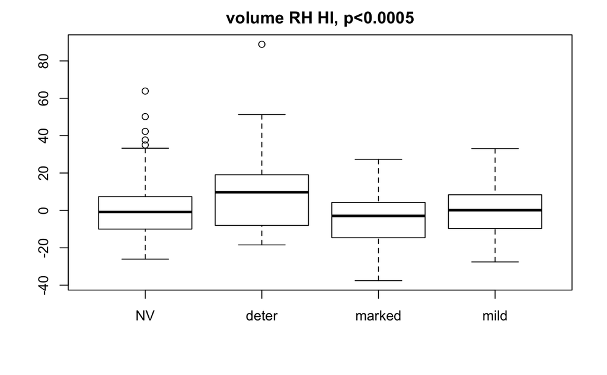

```r
fm = as.formula(mycluster ~ df_clean$OLS_HI_categ)
fit = aov(lm(fm))
boxplot(fm)
title(sprintf('volume RH HI, p<%.4f', summary(fit)[[1]][1, 'Pr(>F)']))
```

And finally, the logistic regression:

```r
library(nnet)
fit <- multinom(df_clean$OLS_HI_categ ~ scale(mycluster), na.action=na.omit)
z <- summary(fit)$coefficients/summary(fit)$standard.errors
p <- (1 - pnorm(abs(z), 0, 1)) * 2
rr = exp(coef(fit))
pp = fitted(fit)
print(p)
```

```
        (Intercept) scale(mycluster)
deter  1.786218e-06      0.042812682
marked 4.800552e-01      0.008702791
mild   1.201435e-03      0.722493989
```

```r
print(fit)
```

```
Call:
multinom(formula = df_clean$OLS_HI_categ ~ scale(mycluster),
    na.action = na.omit)

Coefficients:
       (Intercept) scale(mycluster)
deter    -1.135264       0.40504008
marked   -0.120106      -0.51601391
mild     -0.626888      -0.07276213

Residual Deviance: 556.5239
AIC: 568.5239
```

```r
print(rr)
```

```
       (Intercept) scale(mycluster)
deter    0.3213372        1.4993626
marked   0.8868264        0.5968951
mild     0.5342518        0.9298220
```

Now both deterioration and marked improvement are significant when compared to NVs:

- A one-unit increase in the volume of the right hemisphere cluster variable (i.e. increase by 1 SD) is associated with an decrease in the log odds of markedly improving (vs normals) in the amount of .52. Conversely, a one-unit increase is associated with an increase in the log odds of deterioration of .41.
- In terms of relative risk ratio, a one-unit increase in the the volume of that brain cluster yields a relative risk ratio of 1.5 of deterioration, and .6 marked improvement.

## DTI

Let’s move on to the DTI clusters:

```r
load('~/data/baseline_prediction/combined_descriptives_12172018.RData.gz')
clin = read.csv('~/data/baseline_prediction/long_clin_11302018.csv')
df = merge(clin, data, by='MRN')
idx = df$diag_group != 'new_onset'
dti = df[!is.na(df$inatt_AD_clu1) & idx,]
load('~/data/baseline_prediction/dti_rd_voxelwise_n272_09212018.RData.gz')
dti = merge(dti, data, by='MRN') # put mask ids in combined dataset
mprage = read.xls('~/data/baseline_prediction/long_scans_08072018.xlsx',
                  sheet='dti')
dti = merge(dti, mprage, by.x='mask.id', by.y='Mask.ID') # get demographics
qc = read.csv('~/data/baseline_prediction/master_qc.csv')
dti = merge(dti, qc, by.x='mask.id', by.y='Mask.ID') # get QC scores
df = merge(dti, imaging, by='MRN')
df$mvmt = rowMeans(scale(df$norm.trans), scale(df$norm.rot))
dim(df)
```

```
[1]   253 12111
```

```r
pairwise.t.test(df$inatt_AD_clu1.x, df$OLS_inatt_categ, p.adjust.method='none')
```

```
    Pairwise comparisons using t tests with pooled SD

data:  df$inatt_AD_clu1.x and df$OLS_inatt_categ

       NV   deter marked
deter  0.13 -     -
marked 0.40 0.04  -
mild   0.47 0.62  0.19

P value adjustment method: none
```

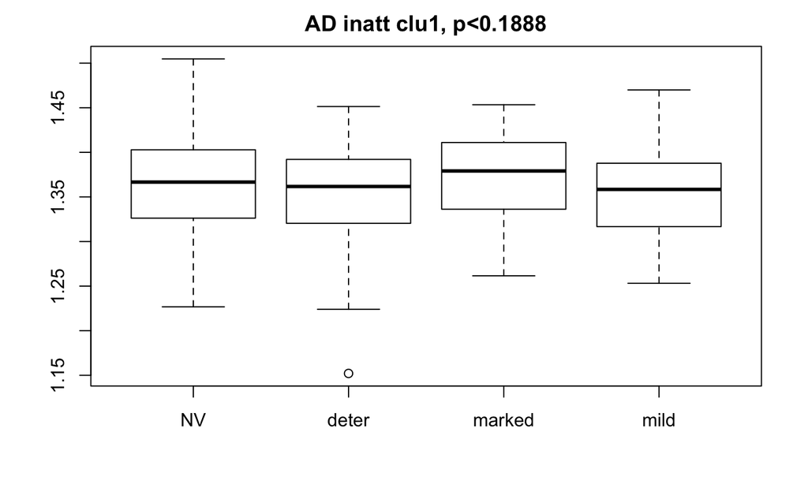

```r
fm = as.formula(df$inatt_AD_clu1.x ~ df$OLS_inatt_categ)
fit = aov(lm(fm))
boxplot(fm)
title(sprintf('AD inatt clu1, p<%.4f', summary(fit)[[1]][1, 'Pr(>F)']))
```

Groups are barely different. What if we residualize them?

```r
bad_nvs = df$OLS_inatt_categ == 'NV' & df$OLS_inatt_slope.x != 0
df_clean = df[!bad_nvs, ]
library(MASS)
res.lm <- lm(inatt_AD_clu1.x ~ Sex + age_at_scan + I(age_at_scan^2) + mvmt + I(mvmt^2), data = df_clean)
step <- stepAIC(res.lm, direction = "both", trace = F)
print(summary(step))
```

```
Call:
lm(formula = inatt_AD_clu1.x ~ Sex + I(age_at_scan^2) + mvmt +
    I(mvmt^2), data = df_clean)

Residuals:
      Min        1Q    Median        3Q       Max
-0.199525 -0.031601  0.003734  0.038526  0.130581

Coefficients:
                   Estimate Std. Error t value Pr(>|t|)
(Intercept)       1.361e+00  9.431e-03 144.289  < 2e-16 ***
SexMale           1.644e-02  7.437e-03   2.211 0.028113 *
I(age_at_scan^2) -2.594e-04  7.584e-05  -3.421 0.000747 ***
mvmt             -2.024e-02  6.175e-03  -3.277 0.001222 **
I(mvmt^2)         9.740e-03  3.192e-03   3.051 0.002564 **
---
Signif. codes:  0 ‘***’ 0.001 ‘**’ 0.01 ‘*’ 0.05 ‘.’ 0.1 ‘ ’ 1

Residual standard error: 0.0507 on 215 degrees of freedom
Multiple R-squared:  0.1071,    Adjusted R-squared:  0.0905
F-statistic: 6.448 on 4 and 215 DF,  p-value: 6.427e-05
```

```r
mycluster = residuals(step)
summary(aov(lm(mycluster ~ df_clean$OLS_inatt_categ)))
```

```
                          Df Sum Sq  Mean Sq F value Pr(>F)
df_clean$OLS_inatt_categ   3 0.0235 0.007829   3.195 0.0244 *
Residuals                216 0.5292 0.002450
---
Signif. codes:  0 ‘***’ 0.001 ‘**’ 0.01 ‘*’ 0.05 ‘.’ 0.1 ‘ ’ 1
```

```r
pairwise.t.test(mycluster, df_clean$OLS_inatt_categ, p.adjust.method='none')
```

```
    Pairwise comparisons using t tests with pooled SD

data:  mycluster and df_clean$OLS_inatt_categ

       NV     deter  marked
deter  0.0253 -      -
marked 0.4047 0.0037 -
mild   0.4450 0.2555 0.1519

P value adjustment method: none
```

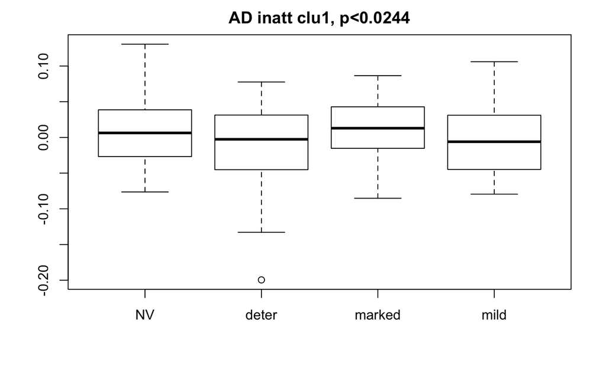

```r
fm = as.formula(mycluster ~ df_clean$OLS_inatt_categ)
fit = aov(lm(fm))
boxplot(fm)
title(sprintf('AD inatt clu1, p<%.4f', summary(fit)[[1]][1, 'Pr(>F)']))
```

Well, group differences did increase when running the brain residuals. Let’s check how the logistic model runs:

```r
library(nnet)
fit <- multinom(df_clean$OLS_inatt_categ ~ scale(mycluster), na.action=na.omit)
z <- summary(fit)$coefficients/summary(fit)$standard.errors
p <- (1 - pnorm(abs(z), 0, 1)) * 2
rr = exp(coef(fit))
pp = fitted(fit)
print(p)
```

```
       (Intercept) scale(mycluster)
deter  0.325866202       0.02946673
marked 0.166616689       0.38452112
mild   0.001686291       0.43674367
```

```r
print(fit)
```

```
Call:
multinom(formula = df_clean$OLS_inatt_categ ~ scale(mycluster),
    na.action = na.omit)

Coefficients:
       (Intercept) scale(mycluster)
deter   -0.1776387       -0.3960456
marked  -0.2553605        0.1679622
mild    -0.6475660       -0.1642714

Residual Deviance: 589.2731
AIC: 601.2731
```

```r
print(rr)
```

```
       (Intercept) scale(mycluster)
deter    0.8372449        0.6729760
marked   0.7746372        1.1828919
mild     0.5233180        0.8485117
```

Apparently I didn’t even plot the second AD inatt cluster in adhd_NOS_descriptives.md. So, let’s switch right to the RD HI cluster:

```r
res.lm <- lm(HI_RD_clu1.x ~ Sex + age_at_scan + I(age_at_scan^2) + mvmt + I(mvmt^2), data = df_clean)
step <- stepAIC(res.lm, direction = "both", trace = F)
print(summary(step))
```

```
Call:
lm(formula = HI_RD_clu1.x ~ age_at_scan + I(age_at_scan^2), data = df_clean)

Residuals:
      Min        1Q    Median        3Q       Max
-0.115183 -0.019980  0.001126  0.020113  0.093554

Coefficients:
                   Estimate Std. Error t value Pr(>|t|)
(Intercept)       0.6674455  0.0250878  26.604  < 2e-16 ***
age_at_scan      -0.0181325  0.0053272  -3.404 0.000792 ***
I(age_at_scan^2)  0.0006607  0.0002719   2.430 0.015915 *
---
Signif. codes:  0 ‘***’ 0.001 ‘**’ 0.01 ‘*’ 0.05 ‘.’ 0.1 ‘ ’ 1

Residual standard error: 0.02942 on 217 degrees of freedom
Multiple R-squared:  0.1722,    Adjusted R-squared:  0.1646
F-statistic: 22.57 on 2 and 217 DF,  p-value: 1.24e-09
```

```r
mycluster = residuals(step)
summary(aov(lm(mycluster ~ df_clean$OLS_HI_categ)))
```

```
                       Df  Sum Sq   Mean Sq F value Pr(>F)
df_clean$OLS_HI_categ   3 0.00633 0.0021093    2.51 0.0597 .
Residuals             216 0.18149 0.0008402
---
Signif. codes:  0 ‘***’ 0.001 ‘**’ 0.01 ‘*’ 0.05 ‘.’ 0.1 ‘ ’ 1
```

```r
pairwise.t.test(mycluster, df_clean$OLS_HI_categ, p.adjust.method='none')
```

```
    Pairwise comparisons using t tests with pooled SD

data:  mycluster and df_clean$OLS_HI_categ

       NV    deter marked
deter  0.347 -     -
marked 0.427 0.114 -
mild   0.066 0.496 0.011

P value adjustment method: none
```

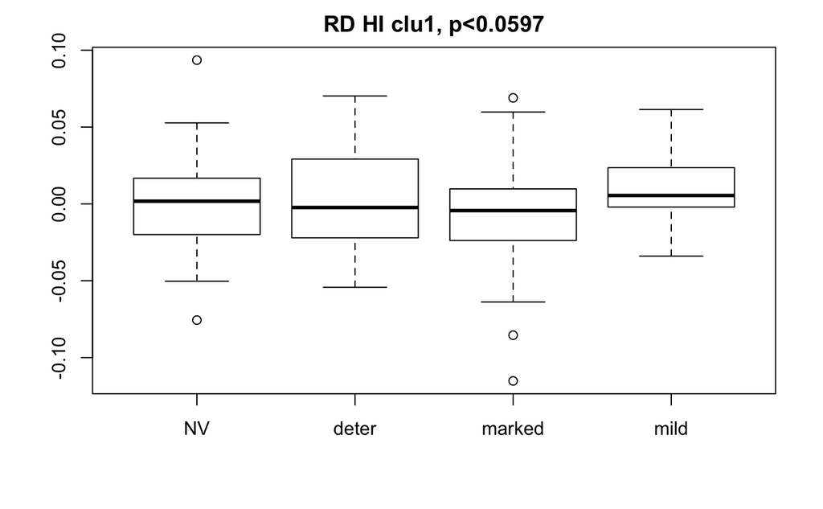

```r
fm = as.formula(mycluster ~ df_clean$OLS_HI_categ)
fit = aov(lm(fm))
boxplot(fm)
title(sprintf('RD HI clu1, p<%.4f', summary(fit)[[1]][1, 'Pr(>F)']))
```

This one looks a bit funky. The only significant difference is between marked and mild??? I’ll skip the logistic model for this one.

## rsFMRI

```r
load('~/data/baseline_prediction/combined_descriptives_12172018.RData.gz')
clin = read.csv('~/data/baseline_prediction/long_clin_11302018.csv')
df = merge(clin, data, by='MRN')
idx = df$diag_group != 'new_onset'
fmri = df[!is.na(df$inatt_melodic_limbic) & idx,]
load('~/data/baseline_prediction/melodic_inter_IC11_12142018.RData.gz')
fmri = merge(fmri, data, by='MRN') # put mask ids in combined dataset
mprage = read.xls('~/data/baseline_prediction/long_scans_08072018.xlsx',
                  sheet='mprage')
fmri = merge(fmri, mprage, by.x='mask.id', by.y='Mask.ID...Scan') # get demographics
qc = read.csv('~/data/baseline_prediction/master_qc.csv')
fmri = merge(fmri, qc, by.x='mask.id', by.y='Mask.ID') # get QC scores
df = merge(fmri, imaging, by='MRN')
dim(df)
```

```
[1]   196 44332
```

```r
bad_nvs = df$OLS_inatt_categ == 'NV' & df$OLS_inatt_slope.x != 0
df_clean = df[!bad_nvs, ]
library(MASS)
res.lm <- lm(inatt_melodic_limbic.x ~ age_at_scan + I(age_at_scan^2) + enormGoodTRs_fmri01 + I(enormGoodTRs_fmri01^2) + Sex...Subjects, data = df_clean)
step <- stepAIC(res.lm, direction = "both", trace = F)
print(summary(step))
```

```
Call:
lm(formula = inatt_melodic_limbic.x ~ I(enormGoodTRs_fmri01^2),
    data = df_clean)

Residuals:
    Min      1Q  Median      3Q     Max
-3.5698 -0.7584 -0.0655  0.8006  4.0456

Coefficients:
                         Estimate Std. Error t value Pr(>|t|)
(Intercept)                 1.959      0.207   9.463  < 2e-16 ***
I(enormGoodTRs_fmri01^2)  135.703     37.971   3.574 0.000458 ***
---
Signif. codes:  0 ‘***’ 0.001 ‘**’ 0.01 ‘*’ 0.05 ‘.’ 0.1 ‘ ’ 1

Residual standard error: 1.302 on 170 degrees of freedom
Multiple R-squared:  0.06988,   Adjusted R-squared:  0.06441
F-statistic: 12.77 on 1 and 170 DF,  p-value: 0.0004579
```

```r
mycluster = residuals(step)
summary(aov(lm(mycluster ~ df_clean$OLS_inatt_categ)))
```

```
                          Df Sum Sq Mean Sq F value   Pr(>F)
df_clean$OLS_inatt_categ   3   38.6  12.868   8.669 2.21e-05 ***
Residuals                168  249.4   1.484
---
Signif. codes:  0 ‘***’ 0.001 ‘**’ 0.01 ‘*’ 0.05 ‘.’ 0.1 ‘ ’ 1
```

```r
pairwise.t.test(mycluster, df_clean$OLS_inatt_categ, p.adjust.method='none')
```

```
    Pairwise comparisons using t tests with pooled SD

data:  mycluster and df_clean$OLS_inatt_categ

       NV     deter   marked
deter  0.0187 -       -
marked 0.0019 1.3e-06 -
mild   0.3757 0.0055  0.0645

P value adjustment method: none
```

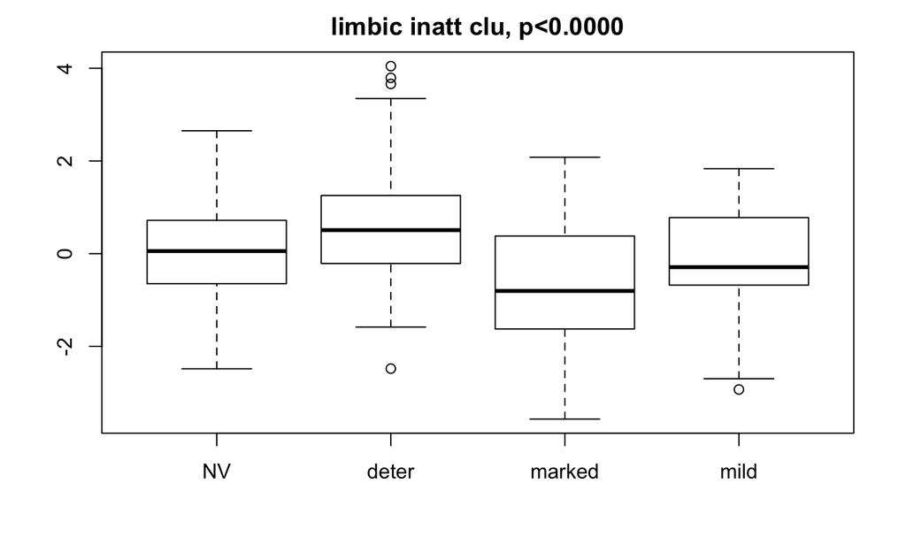

```r
fm = as.formula(mycluster ~ df_clean$OLS_inatt_categ)
fit = aov(lm(fm))
boxplot(fm)
title(sprintf('limbic inatt clu, p<%.4f', summary(fit)[[1]][1, 'Pr(>F)']))
```

```r
library(nnet)
fit <- multinom(df_clean$OLS_inatt_categ ~ scale(mycluster), na.action=na.omit)
z <- summary(fit)$coefficients/summary(fit)$standard.errors
p <- (1 - pnorm(abs(z), 0, 1)) * 2
rr = exp(coef(fit))
pp = fitted(fit)
print(p)
```

```
       (Intercept) scale(mycluster)
deter  0.019498492      0.023673198
marked 0.002316905      0.002209249
mild   0.001042402      0.357950947
```

```r
print(fit)
```

```
Call:
multinom(formula = df_clean$OLS_inatt_categ ~ scale(mycluster),
    na.action = na.omit)

Coefficients:
       (Intercept) scale(mycluster)
deter   -0.4988229        0.4951180
marked  -0.7091552       -0.7627375
mild    -0.7349453       -0.2292594

Residual Deviance: 439.1295
AIC: 451.1295
```

```r
print(rr)
```

```
       (Intercept) scale(mycluster)
deter    0.6072450        1.6406918
marked   0.4920597        0.4663879
mild     0.4795317        0.7951223
```

```r
res.lm <- lm(inatt_melodic_VAN.x ~ age_at_scan + I(age_at_scan^2) + enormGoodTRs_fmri01 + I(enormGoodTRs_fmri01^2) + Sex...Subjects, data = df_clean)
step <- stepAIC(res.lm, direction = "both", trace = F)
print(summary(step))
```

```
Call:
lm(formula = inatt_melodic_VAN.x ~ 1, data = df_clean)

Residuals:
    Min      1Q  Median      3Q     Max
-2.3466 -0.6242 -0.0249  0.6358  3.5330

Coefficients:
            Estimate Std. Error t value Pr(>|t|)
(Intercept) -0.14339    0.07286  -1.968   0.0507 .
---
Signif. codes:  0 ‘***’ 0.001 ‘**’ 0.01 ‘*’ 0.05 ‘.’ 0.1 ‘ ’ 1

Residual standard error: 0.9555 on 171 degrees of freedom
```

```r
mycluster = residuals(step)
summary(aov(lm(mycluster ~ df_clean$OLS_inatt_categ)))
```

```
                          Df Sum Sq Mean Sq F value   Pr(>F)
df_clean$OLS_inatt_categ   3  29.55   9.849   13.07 1.03e-07 ***
Residuals                168 126.57   0.753
---
Signif. codes:  0 ‘***’ 0.001 ‘**’ 0.01 ‘*’ 0.05 ‘.’ 0.1 ‘ ’ 1
```

```r
pairwise.t.test(mycluster, df_clean$OLS_inatt_categ, p.adjust.method='none')
```

```
    Pairwise comparisons using t tests with pooled SD

data:  mycluster and df_clean$OLS_inatt_categ

       NV      deter   marked
deter  0.00146 -       -
marked 0.00033 3.1e-09 -
mild   0.92822 0.00598 0.00293

P value adjustment method: none
```

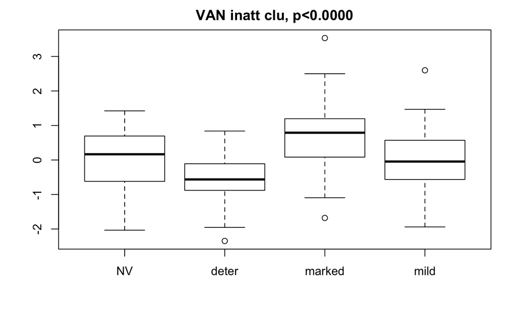

```r
fm = as.formula(mycluster ~ df_clean$OLS_inatt_categ)
fit = aov(lm(fm))
boxplot(fm)
title(sprintf('VAN inatt clu, p<%.4f', summary(fit)[[1]][1, 'Pr(>F)']))
```

```r
library(nnet)
fit <- multinom(df_clean$OLS_inatt_categ ~ scale(mycluster), na.action=na.omit)
z <- summary(fit)$coefficients/summary(fit)$standard.errors
p <- (1 - pnorm(abs(z), 0, 1)) * 2
rr = exp(coef(fit))
pp = fitted(fit)
print(p)
```

```
       (Intercept) scale(mycluster)
deter  0.008866146      0.001859404
marked 0.001055448      0.001009699
mild   0.001097881      0.925969668
```

```r
print(fit)
```

```
Call:
multinom(formula = df_clean$OLS_inatt_categ ~ scale(mycluster),
    na.action = na.omit)

Coefficients:
       (Intercept) scale(mycluster)
deter   -0.5875931       -0.7442652
marked  -0.8006234        0.8580352
mild    -0.7260057        0.0234347

Residual Deviance: 427.9816
AIC: 439.9816
```

```r
print(rr)
```

```
       (Intercept) scale(mycluster)
deter    0.5556631        0.4750832
marked   0.4490489        2.3585221
mild     0.4838377        1.0237115
```

```r
res.lm <- lm(inatt_melodic_DMN.x ~ age_at_scan + I(age_at_scan^2) + enormGoodTRs_fmri01 + I(enormGoodTRs_fmri01^2) + Sex...Subjects, data = df_clean)
step <- stepAIC(res.lm, direction = "both", trace = F)
print(summary(step))
```

```
Call:
lm(formula = inatt_melodic_DMN.x ~ age_at_scan, data = df_clean)

Residuals:
    Min      1Q  Median      3Q     Max
-3.2103 -0.8647 -0.0484  0.7327  3.2335

Coefficients:
            Estimate Std. Error t value Pr(>|t|)
(Intercept)  0.67173    0.44040   1.525    0.129
age_at_scan -0.06672    0.04265  -1.564    0.120

Residual standard error: 1.217 on 170 degrees of freedom
Multiple R-squared:  0.01419,   Adjusted R-squared:  0.008393
F-statistic: 2.447 on 1 and 170 DF,  p-value: 0.1196
```

```r
mycluster = residuals(step)
summary(aov(lm(mycluster ~ df_clean$OLS_inatt_categ)))
```

```
                          Df Sum Sq Mean Sq F value Pr(>F)
df_clean$OLS_inatt_categ   3  12.75   4.250   2.988 0.0327 *
Residuals                168 239.00   1.423
---
Signif. codes:  0 ‘***’ 0.001 ‘**’ 0.01 ‘*’ 0.05 ‘.’ 0.1 ‘ ’ 1
```

```r
pairwise.t.test(mycluster, df_clean$OLS_inatt_categ, p.adjust.method='none')
```

```
    Pairwise comparisons using t tests with pooled SD

data:  mycluster and df_clean$OLS_inatt_categ

       NV     deter  marked
deter  0.2355 -      -
marked 0.0472 0.0042 -
mild   0.4753 0.0983 0.2986

P value adjustment method: none
```

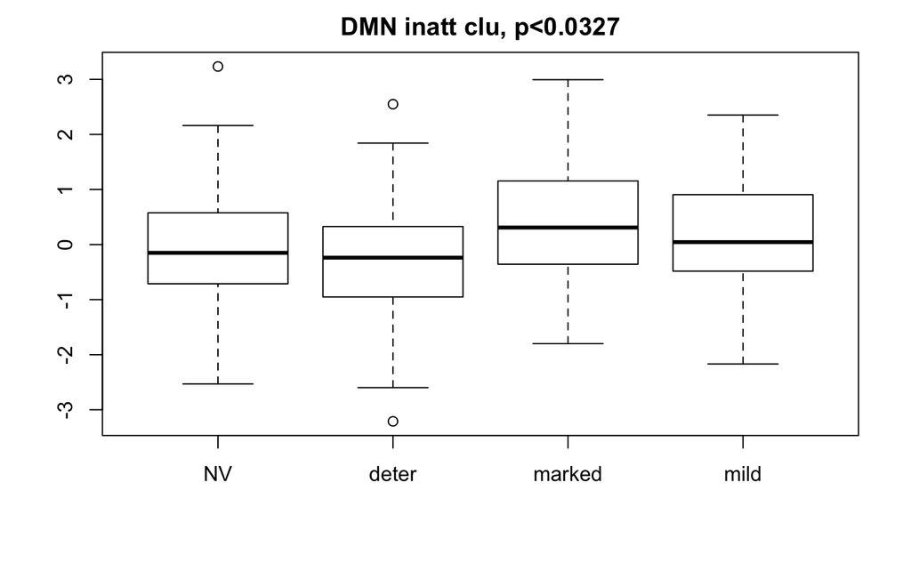

```r
fm = as.formula(mycluster ~ df_clean$OLS_inatt_categ)
fit = aov(lm(fm))
boxplot(fm)
title(sprintf('DMN inatt clu, p<%.4f', summary(fit)[[1]][1, 'Pr(>F)']))
```

```r
library(nnet)
fit <- multinom(df_clean$OLS_inatt_categ ~ scale(mycluster), na.action=na.omit)
z <- summary(fit)$coefficients/summary(fit)$standard.errors
p <- (1 - pnorm(abs(z), 0, 1)) * 2
rr = exp(coef(fit))
pp = fitted(fit)
print(p)
```

```
       (Intercept) scale(mycluster)
deter  0.044758138       0.22988868
marked 0.007420093       0.04927563
mild   0.001089056       0.47120425
```

```r
print(fit)
```

```
Call:
multinom(formula = df_clean$OLS_inatt_categ ~ scale(mycluster),
    na.action = na.omit)

Coefficients:
       (Intercept) scale(mycluster)
deter   -0.4092325       -0.2493409
marked  -0.5786556        0.4268344
mild    -0.7293981        0.1648055

Residual Deviance: 455.3128
AIC: 467.3128
```

```r
print(rr)
```

```
       (Intercept) scale(mycluster)
deter    0.6641598        0.7793143
marked   0.5606516        1.5323988
mild     0.4821991        1.1791637
```

TODO:

- where is that structural cluster actually? (whereami)
- what if we residualize the brain to begin with, using our step function? use lme?